# Movies-Galore.R

91827

2023-12-01

```r
#============================================================================
# BANL 6100
# Project
# Movies Galore
# Fall 2023

setwd("~/arodsclass")
remove(list = ls())
graphics.off()
options(digits = 3, scipen = 9999)

library(tidyverse)
library(rvest)
library(janitor)
library(lubridate)
```

I have assembled data on the top 100 Biggest Movie budgets and Performance of all times. I took it from:

```r
url = "https://www.the-numbers.com/movie/budgets/all"
```

the dataset is attached: i called it my moviedata i also created a subset: moviedata1. The subset contains sum of worldwide gross by year (YearGross); and it also contains number of films per year (NumberFilms). 1. Show the Worldwide Year Gross per year in a ggplot barchart - properly labeled 2. Show the Number of Films per year in a ggplot barchart or column chart 3. Calculate a third variable PerFilm = YearGross/NumberFilms and display in a barchart. 4. Repeat the task in 1 above but only films from 2019 and after. 5. 2019 seems to be a banner year; repeat the task in 4 but only for the year 2019. 6. Provide a ggplot column chart listing the titles of the 2019 movies and their Worldwide Gross 7. Provide a ggplot column chart listing the titles of movies from both 2015 2019 and their Worldwide Gross

8. The reported worldwide gross is in nominal dollars; use the CPI from FRED and convert the 2015 and 2019 Worldwide Gross to 2023 dollars; call this new variable RealWorldwideGross. Redo the graph in 7 above.

```r
# ======================================  #
library(readr)
moviedata1 <- read_csv("moviedata1.csv")
```

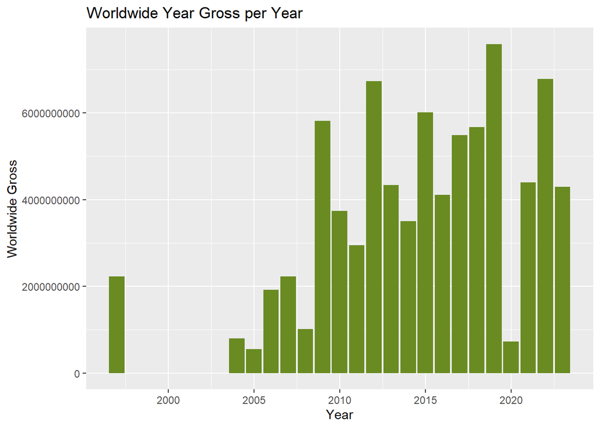

```r
View(moviedata1)
# 1. Show the Worldwide Year Gross per year in a ggplot barchart - properly labeled
ggplot(moviedata1, aes(x = Year, y = YearGross)) +
  geom_bar(stat = "identity", fill = "olivedrab4") +
  labs(title = "Worldwide Year Gross per Year",
       x = "Year",
       y = "Worldwide Gross")
```

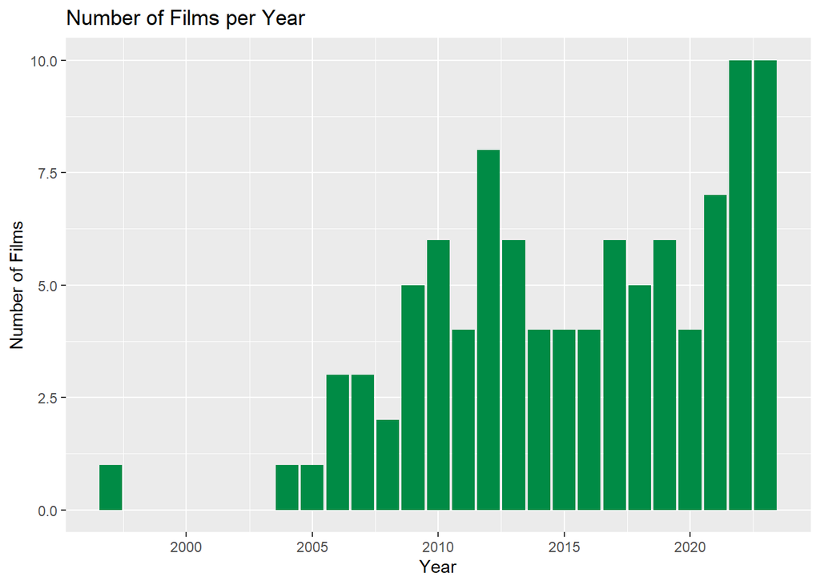

```r
# 2. Show the Number of Films per year in a ggplot barchart or column chart
ggplot(moviedata1, aes(x = Year, y = NumberFilms)) +
  geom_bar(stat = "identity", fill = "springgreen4") +
  labs(title = "Number of Films per Year",
       x = "Year",
       y = "Number of Films")
```

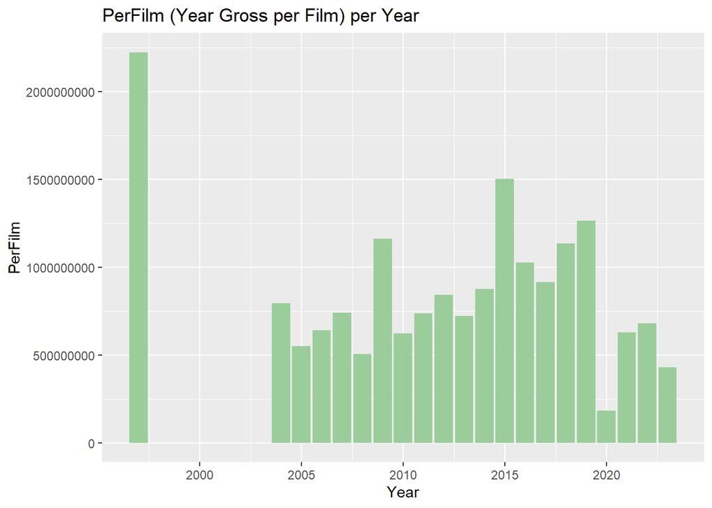

```r
# 3. Calculate a third variable PerFilm = YearGross / NumberFilms and display in a barchart
moviedata1$PerFilm <- moviedata1$YearGross / moviedata1$NumberFilms
ggplot(moviedata1, aes(x = Year, y = PerFilm)) +
  geom_bar(stat = "identity", fill = "darkseagreen3") +
  labs(title = "PerFilm (Year Gross per Film) per Year",
       x = "Year",
       y = "PerFilm")
```

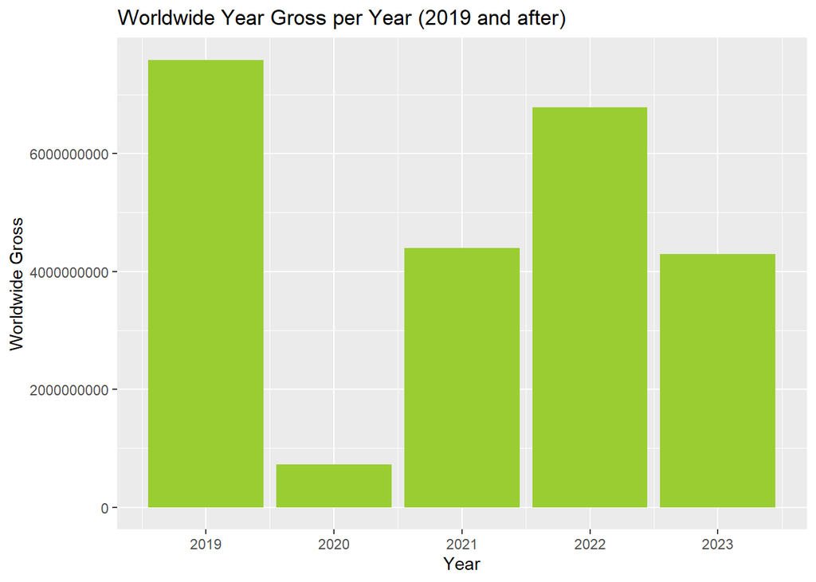

```r
# 4. Repeat the task in 1 above but only for films from 2019 and after.
ggplot(moviedata1[moviedata1$Year >= 2019, ], aes(x = Year, y = YearGross)) +
  geom_bar(stat = "identity", fill = "yellowgreen") +
  labs(title = "Worldwide Year Gross per Year (2019 and after)",
       x = "Year",
       y = "Worldwide Gross")
```

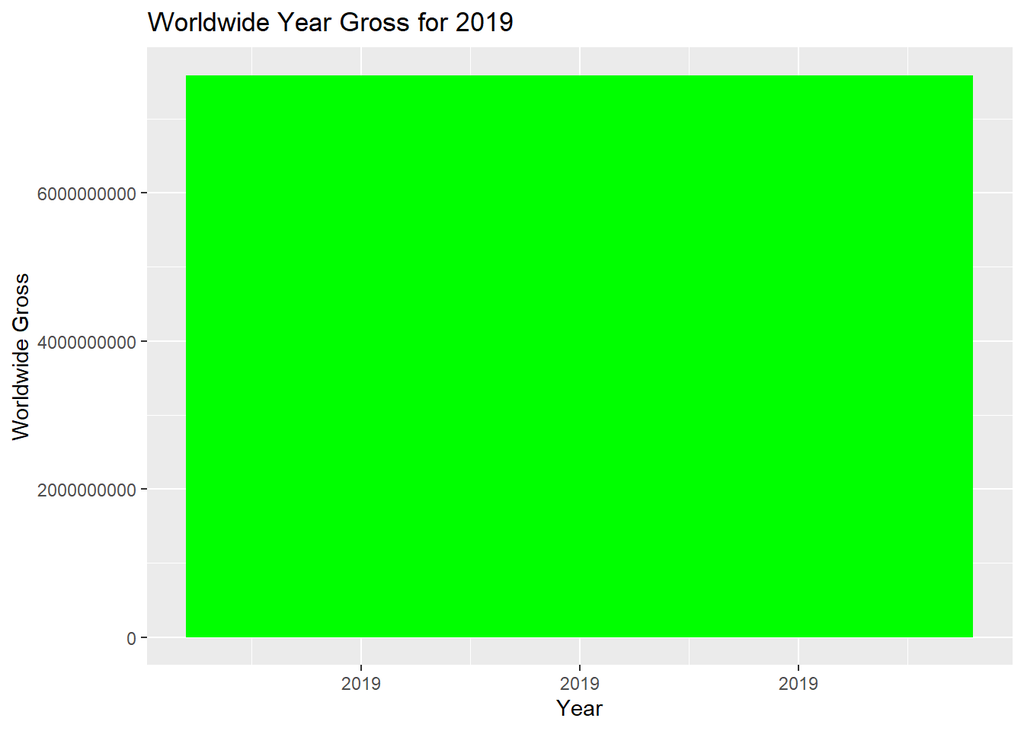

```r
# 5. Repeat the task in 4 but only for the year 2019.
ggplot(moviedata1[moviedata1$Year == 2019, ], aes(x = Year, y = YearGross)) +
  geom_bar(stat = "identity", fill = "green") +
  labs(title = "Worldwide Year Gross for 2019",
       x = "Year",
       y = "Worldwide Gross")
```

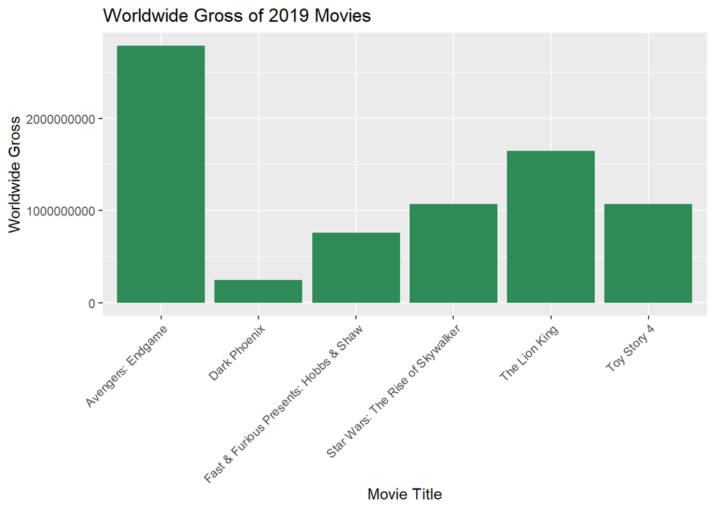

```r
# 6. Provide a ggplot column chart listing the titles of the 2019 movies and their Worldwide Gross
library(readr)
moviedata <- read_csv("moviedata.csv")
View(moviedata)
movies_2019 <- moviedata[moviedata$Year == 2019, ]
ggplot(movies_2019, aes(x = Movie, y = WorldwideGross)) +
  geom_col(fill = "seagreen") +
  labs(title = "Worldwide Gross of 2019 Movies",
       x = "Movie Title",
       y = "Worldwide Gross") +
  theme(axis.text.x = element_text(angle = 45, hjust = 1))
```

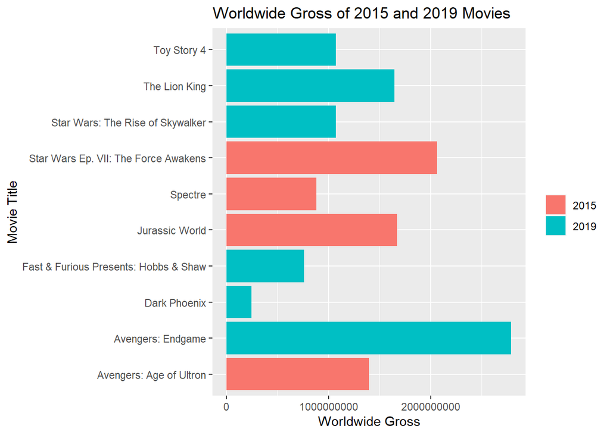

```r
# 7. Provide a ggplot column chart listing the titles of movies from both 2015 and 2019 and their Worldwide Gross
movies_2015_2019 <- moviedata[moviedata$Year %in% c(2015, 2019), ]
ggplot(movies_2015_2019, aes(x = Movie, y = WorldwideGross, fill = as.factor(Year))) +
  geom_col(position = "dodge") +
  labs(title = "Worldwide Gross of 2015 and 2019 Movies",
       x = "Movie Title",
       y = "Worldwide Gross") +
  theme(legend.title = element_blank())+coord_flip()
```

```r
# 8. The reported worldwide gross is in nominal dollars; use the CPI from FRED to convert the 2015 and 2019 Worldwide Gross to 2023 dollars; call this new variable RealWorldwideGross and redo the graph in 7 above.
# You'll need to download CPI data, adjust the values, and perform the currency conversion, which may require additional code and data sources. You can use the "quantmod" package to get CPI data from FRED and then adjust the worldwide gross values to 2023 dollars before plotting.

library(readxl)
file_path <- "~/arodsclass/CPIAUCSL.xls"
cpi_data1 <- read_excel(file_path)
summary(cpi_data1)
```

```
##  observation_date                    CPIAUCSL
##  Min.   :1947-01-01 00:00:00.00   Min.   : 22.3
##  1st Qu.:1966-01-01 00:00:00.00   1st Qu.: 32.2
##  Median :1985-01-01 00:00:00.00   Median :105.8
##  Mean   :1984-12-31 14:57:39.74   Mean   :116.6
##  3rd Qu.:2004-01-01 00:00:00.00   3rd Qu.:185.2
##  Max.   :2023-01-01 00:00:00.00   Max.   :292.6
##                                   NA's   :1
```

```r
#cpi_data1 = read.csv("CPIAUCSL.csv")
print(cpi_data1)
```

```
## # A tibble: 77 × 2
##    observation_date    CPIAUCSL
##    <dttm>                 <dbl>
##  1 1947-01-01 00:00:00     22.3
##  2 1948-01-01 00:00:00     24.0
##  3 1949-01-01 00:00:00     23.8
##  4 1950-01-01 00:00:00     24.1
##  5 1951-01-01 00:00:00     26.0
##  6 1952-01-01 00:00:00     26.6
##  7 1953-01-01 00:00:00     26.8
##  8 1954-01-01 00:00:00     26.9
##  9 1955-01-01 00:00:00     26.8
## 10 1956-01-01 00:00:00     27.2
## # ℹ 67 more rows
```

```r
Cpiyear <- format(as.Date(cpi_data1$observation_date, format = "%m-%d-%Y"), "%Y")
#cpi_data1$YearNumeric <- as.numeric(format(as.Date(cpi_data1$DATE, format = "%m-%d-%Y"), "%Y"))
print(Cpiyear)
```

```
##  [1] "1947" "1948" "1949" "1950" "1951" "1952" "1953" "1954" "1955" "1956"
## [11] "1957" "1958" "1959" "1960" "1961" "1962" "1963" "1964" "1965" "1966"
## [21] "1967" "1968" "1969" "1970" "1971" "1972" "1973" "1974" "1975" "1976"
## [31] "1977" "1978" "1979" "1980" "1981" "1982" "1983" "1984" "1985" "1986"
## [41] "1987" "1988" "1989" "1990" "1991" "1992" "1993" "1994" "1995" "1996"
## [51] "1997" "1998" "1999" "2000" "2001" "2002" "2003" "2004" "2005" "2006"
## [61] "2007" "2008" "2009" "2010" "2011" "2012" "2013" "2014" "2015" "2016"
## [71] "2017" "2018" "2019" "2020" "2021" "2022" "2023"
```

```r
print(cpi_data1)
```

```
## # A tibble: 77 × 2
##    observation_date    CPIAUCSL
##    <dttm>                 <dbl>
##  1 1947-01-01 00:00:00     22.3
##  2 1948-01-01 00:00:00     24.0
##  3 1949-01-01 00:00:00     23.8
##  4 1950-01-01 00:00:00     24.1
##  5 1951-01-01 00:00:00     26.0
##  6 1952-01-01 00:00:00     26.6
##  7 1953-01-01 00:00:00     26.8
##  8 1954-01-01 00:00:00     26.9
##  9 1955-01-01 00:00:00     26.8
## 10 1956-01-01 00:00:00     27.2
## # ℹ 67 more rows
```

```r
yearnumeric <- as.numeric(Cpiyear)

class(yearnumeric)
```

```
## [1] "numeric"
```

```r
y<-yearnumeric

names(y) <- "y"
y
```

```
##    y <NA> <NA> <NA> <NA> <NA> <NA> <NA> <NA> <NA> <NA> <NA> <NA> <NA> <NA> <NA>
## 1947 1948 1949 1950 1951 1952 1953 1954 1955 1956 1957 1958 1959 1960 1961 1962
## <NA> <NA> <NA> <NA> <NA> <NA> <NA> <NA> <NA> <NA> <NA> <NA> <NA> <NA> <NA> <NA>
## 1963 1964 1965 1966 1967 1968 1969 1970 1971 1972 1973 1974 1975 1976 1977 1978
## <NA> <NA> <NA> <NA> <NA> <NA> <NA> <NA> <NA> <NA> <NA> <NA> <NA> <NA> <NA> <NA>
## 1979 1980 1981 1982 1983 1984 1985 1986 1987 1988 1989 1990 1991 1992 1993 1994
## <NA> <NA> <NA> <NA> <NA> <NA> <NA> <NA> <NA> <NA> <NA> <NA> <NA> <NA> <NA> <NA>
## 1995 1996 1997 1998 1999 2000 2001 2002 2003 2004 2005 2006 2007 2008 2009 2010
## <NA> <NA> <NA> <NA> <NA> <NA> <NA> <NA> <NA> <NA> <NA> <NA> <NA>
## 2011 2012 2013 2014 2015 2016 2017 2018 2019 2020 2021 2022 2023
```

```r
df<-data.frame(y=y)

merged_data<-cbind(cpi_data1,y)

merged_data
```

```
##    observation_date CPIAUCSL    y
## 1        1947-01-01     22.3 1947
## 2        1948-01-01     24.0 1948
## 3        1949-01-01     23.8 1949
## 4        1950-01-01     24.1 1950
## 5        1951-01-01     26.0 1951
## 6        1952-01-01     26.6 1952
## 7        1953-01-01     26.8 1953
## 8        1954-01-01     26.9 1954
## 9        1955-01-01     26.8 1955
## 10       1956-01-01     27.2 1956
## 11       1957-01-01     28.1 1957
## 12       1958-01-01     28.9 1958
## 13       1959-01-01     29.1 1959
## 14       1960-01-01     29.6 1960
```

[output cut: 63 more lines]

```r
merged_data$CPICAUCSL <- merged_data$CPICAUCSL
class(merged_data)
```

```
## [1] "data.frame"
```

```r
cpi_2015 <- merged_data[merged_data$y == "2015", "CPIAUCSL"]
cpi_2019 <- merged_data[merged_data$y == "2019", "CPIAUCSL"]
cpi_2022 <- merged_data[merged_data$y == "2022", "CPIAUCSL"]

as.numeric(cpi_2015)
```

```
## [1] 237
```

```r
as.numeric(cpi_2019)
```

```
## [1] 256
```

```r
as.numeric(cpi_2022)
```

```
## [1] 293
```

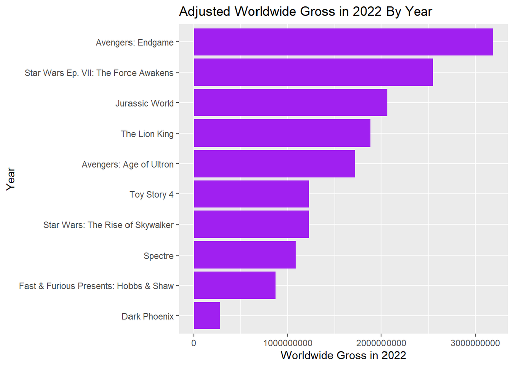

```r
inflation_2015_to_2022 <- cpi_2022 / cpi_2015
inflation_2019_to_2022 <- cpi_2022 / cpi_2019

moviedata$RealWorldwideGross <-ifelse(moviedata$Year ==2015,
                                      moviedata$WorldwideGross*inflation_2015_to_2022,
                                      ifelse(moviedata$Year==2019,
                                             moviedata$WorldwideGross*inflation_2019_to_2022,moviedata$WorldwideGross))

filter7<- moviedata%>%filter(Year %in% c(2015, 2019))

ggplot(data = filter7, aes(x = reorder(Movie,RealWorldwideGross), y = RealWorldwideGross)) +
  geom_bar(stat = "identity", fill = "Purple") +
  labs(x = "Year", y = "Worldwide Gross in 2022") +
  ggtitle("Adjusted Worldwide Gross in 2022 By Year") +
  coord_flip()
```

```r
#
```